# Risk Factor Analysis

## Outcome Variable

**Outcome Variable:** whz

## Predictor Variables

**Intervention Variable:** meducyrs

**Adjustment Set:**

- arm
- W_mage
- feducyrs
- W_mhtcm
- single
- W_nrooms
- impsan
- W_gagebrth
- W_birthwt
- W_birthlen
- vagbrth
- parity
- delta_W_mage
- delta_feducyrs
- delta_W_mhtcm
- delta_single
- delta_W_nrooms
- delta_impsan
- delta_W_gagebrth
- delta_W_birthwt
- delta_W_birthlen
- delta_vagbrth
- delta_parity

## Stratifying Variables

The analysis was stratified on these variable(s):

- agecat
- studyid
- country

## Data Summary

| agecat | studyid | country | meducyrs | n_cell | n |
| --- | --- | --- | --- | --- | --- |
| 6 months | ki0047075b-MAL-ED | BANGLADESH | High | 73 | 196 |
| 6 months | ki0047075b-MAL-ED | BANGLADESH | Low | 64 | 196 |
| 6 months | ki0047075b-MAL-ED | BANGLADESH | Medium | 59 | 196 |
| 6 months | ki0047075b-MAL-ED | BRAZIL | High | 71 | 208 |
| 6 months | ki0047075b-MAL-ED | BRAZIL | Low | 56 | 208 |
| 6 months | ki0047075b-MAL-ED | BRAZIL | Medium | 81 | 208 |
| 6 months | ki0047075b-MAL-ED | INDIA | High | 59 | 208 |
| 6 months | ki0047075b-MAL-ED | INDIA | Low | 72 | 208 |
| 6 months | ki0047075b-MAL-ED | INDIA | Medium | 77 | 208 |
| 6 months | ki0047075b-MAL-ED | NEPAL | High | 53 | 221 |
| 6 months | ki0047075b-MAL-ED | NEPAL | Low | 93 | 221 |
| 6 months | ki0047075b-MAL-ED | NEPAL | Medium | 75 | 221 |
| 6 months | ki0047075b-MAL-ED | PERU | High | 81 | 272 |
| 6 months | ki0047075b-MAL-ED | PERU | Low | 94 | 272 |
| 6 months | ki0047075b-MAL-ED | PERU | Medium | 97 | 272 |
| 6 months | ki0047075b-MAL-ED | SOUTH AFRICA | High | 70 | 254 |
| 6 months | ki0047075b-MAL-ED | SOUTH AFRICA | Low | 127 | 254 |
| 6 months | ki0047075b-MAL-ED | SOUTH AFRICA | Medium | 57 | 254 |
| 6 months | ki0047075b-MAL-ED | TANZANIA, UNITED REPUBLIC OF | High | 9 | 203 |
| 6 months | ki0047075b-MAL-ED | TANZANIA, UNITED REPUBLIC OF | Low | 62 | 203 |
| 6 months | ki0047075b-MAL-ED | TANZANIA, UNITED REPUBLIC OF | Medium | 132 | 203 |
| 6 months | ki1000108-CMC-V-BCS-2002 | INDIA | High | 157 | 368 |
| 6 months | ki1000108-CMC-V-BCS-2002 | INDIA | Low | 104 | 368 |
| 6 months | ki1000108-CMC-V-BCS-2002 | INDIA | Medium | 107 | 368 |
| 6 months | ki1000108-IRC | INDIA | High | 124 | 408 |
| 6 months | ki1000108-IRC | INDIA | Low | 145 | 408 |
| 6 months | ki1000108-IRC | INDIA | Medium | 139 | 408 |
| 6 months | ki1000109-EE | PAKISTAN | High | 15 | 373 |
| 6 months | ki1000109-EE | PAKISTAN | Low | 325 | 373 |
| 6 months | ki1000109-EE | PAKISTAN | Medium | 33 | 373 |

[output cut: 114 more lines]

The following strata were considered:

- agecat: 24 months, studyid: ki0047075b-MAL-ED, country: BANGLADESH
- agecat: 24 months, studyid: ki0047075b-MAL-ED, country: BRAZIL
- agecat: 24 months, studyid: ki0047075b-MAL-ED, country: INDIA
- agecat: 24 months, studyid: ki0047075b-MAL-ED, country: NEPAL
- agecat: 24 months, studyid: ki0047075b-MAL-ED, country: PERU
- agecat: 24 months, studyid: ki0047075b-MAL-ED, country: SOUTH AFRICA
- agecat: 24 months, studyid: ki0047075b-MAL-ED, country: TANZANIA, UNITED REPUBLIC OF
- agecat: 24 months, studyid: ki1000108-CMC-V-BCS-2002, country: INDIA
- agecat: 24 months, studyid: ki1000108-IRC, country: INDIA
- agecat: 24 months, studyid: ki1017093-NIH-Birth, country: BANGLADESH
- agecat: 24 months, studyid: ki1017093b-PROVIDE, country: BANGLADESH
- agecat: 24 months, studyid: ki1017093c-NIH-Crypto, country: BANGLADESH
- agecat: 24 months, studyid: ki1066203-TanzaniaChild2, country: TANZANIA, UNITED REPUBLIC OF
- agecat: 24 months, studyid: ki1113344-GMS-Nepal, country: NEPAL
- agecat: 24 months, studyid: ki1119695-PROBIT, country: BELARUS
- agecat: 24 months, studyid: ki1126311-ZVITAMBO, country: ZIMBABWE
- agecat: 24 months, studyid: ki1135781-COHORTS, country: GUATEMALA
- agecat: 24 months, studyid: ki1135781-COHORTS, country: INDIA
- agecat: 24 months, studyid: ki1135781-COHORTS, country: PHILIPPINES
- agecat: 24 months, studyid: ki1148112-LCNI-5, country: MALAWI
- agecat: 24 months, studyid: kiGH5241-JiVitA-3, country: BANGLADESH
- agecat: 24 months, studyid: kiGH5241-JiVitA-4, country: BANGLADESH
- agecat: 6 months, studyid: ki0047075b-MAL-ED, country: BANGLADESH
- agecat: 6 months, studyid: ki0047075b-MAL-ED, country: BRAZIL
- agecat: 6 months, studyid: ki0047075b-MAL-ED, country: INDIA
- agecat: 6 months, studyid: ki0047075b-MAL-ED, country: NEPAL
- agecat: 6 months, studyid: ki0047075b-MAL-ED, country: PERU
- agecat: 6 months, studyid: ki0047075b-MAL-ED, country: SOUTH AFRICA
- agecat: 6 months, studyid: ki0047075b-MAL-ED, country: TANZANIA, UNITED REPUBLIC OF
- agecat: 6 months, studyid: ki1000108-CMC-V-BCS-2002, country: INDIA
- agecat: 6 months, studyid: ki1000108-IRC, country: INDIA
- agecat: 6 months, studyid: ki1000109-EE, country: PAKISTAN
- agecat: 6 months, studyid: ki1000304b-SAS-CompFeed, country: INDIA
- agecat: 6 months, studyid: ki1000304b-SAS-FoodSuppl, country: INDIA
- agecat: 6 months, studyid: ki1017093-NIH-Birth, country: BANGLADESH
- agecat: 6 months, studyid: ki1017093b-PROVIDE, country: BANGLADESH
- agecat: 6 months, studyid: ki1017093c-NIH-Crypto, country: BANGLADESH
- agecat: 6 months, studyid: ki1066203-TanzaniaChild2, country: TANZANIA, UNITED REPUBLIC OF
- agecat: 6 months, studyid: ki1112895-Guatemala BSC, country: GUATEMALA
- agecat: 6 months, studyid: ki1113344-GMS-Nepal, country: NEPAL
- agecat: 6 months, studyid: ki1119695-PROBIT, country: BELARUS
- agecat: 6 months, studyid: ki1126311-ZVITAMBO, country: ZIMBABWE
- agecat: 6 months, studyid: ki1135781-COHORTS, country: GUATEMALA
- agecat: 6 months, studyid: ki1135781-COHORTS, country: INDIA
- agecat: 6 months, studyid: ki1135781-COHORTS, country: PHILIPPINES
- agecat: 6 months, studyid: ki1148112-LCNI-5, country: MALAWI
- agecat: 6 months, studyid: kiGH5241-JiVitA-3, country: BANGLADESH
- agecat: 6 months, studyid: kiGH5241-JiVitA-4, country: BANGLADESH

### Dropped Strata

Some strata were dropped due to rare outcomes:

- agecat: 24 months, studyid: ki1066203-TanzaniaChild2, country: TANZANIA, UNITED REPUBLIC OF

## Methods Detail

We’re interested in the causal parameters $E[Y_a]$ for all values of $a \in \mathcal{A}$. These parameters represent the mean outcome if, possibly contrary to fact, we intervened to set all units to have $A=a$. Under the randomization and positivity assumptions, these are identified by the statistical parameters $\psi_a=E_W[E_{Y|A,W}(Y|A=a,W)]$. In addition, we’re interested in the mean of $Y$, $E[Y]$ under no intervention (the observed mean). We will estimate these parameters by using SuperLearner to fit the relevant likelihood factors – $E_{Y|A,W}(Y|A=a,W)$ and $p(A=a|W)$, and then updating our likelihood fit using a joint TMLE.

For unadjusted analyses ($W=\{\}$), initial likelihoods were estimated using Lrnr_glm to estimate the simple $E(Y|A)$ and Lrnr_mean to estimate $p(A)$. For adjusted analyses, a small library containing Lrnr_glmnet, Lrnr_xgboost, and Lrnr_mean was used.

Having estimated these parameters, we will then use the delta method to estimate relative risks and attributable risks relative to a prespecified baseline level of $A$.

# Results Detail

## Results Plots

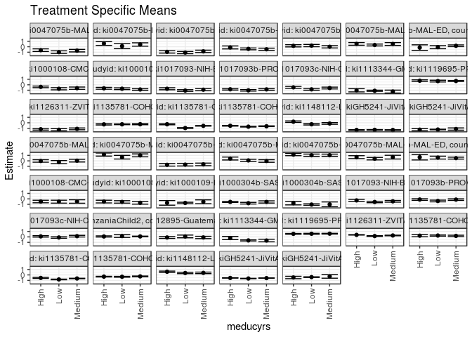

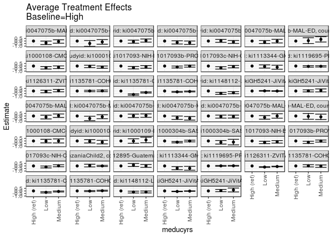

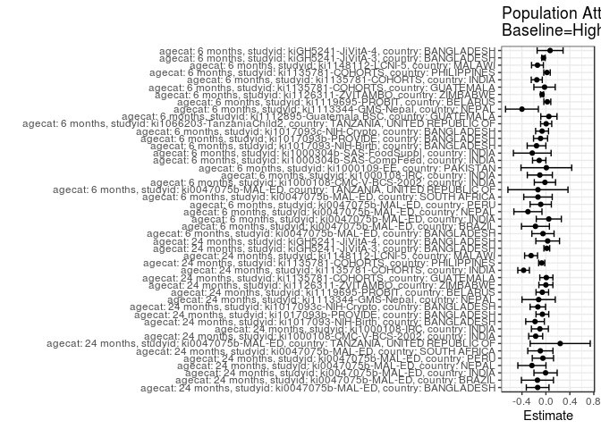

## Results Table

### Parameter: TSM

| agecat | studyid | country | intervention_level | baseline_level | estimate | ci_lower | ci_upper |
| --- | --- | --- | --- | --- | --- | --- | --- |
| 6 months | ki0047075b-MAL-ED | BANGLADESH | High | NA | -0.0241031 | -0.2533805 | 0.2051744 |
| 6 months | ki0047075b-MAL-ED | BANGLADESH | Low | NA | -0.2331986 | -0.5195673 | 0.0531701 |
| 6 months | ki0047075b-MAL-ED | BANGLADESH | Medium | NA | 0.0332069 | -0.2131267 | 0.2795406 |
| 6 months | ki0047075b-MAL-ED | BRAZIL | High | NA | 1.1486126 | 0.8659618 | 1.4312635 |
| 6 months | ki0047075b-MAL-ED | BRAZIL | Low | NA | 0.6624130 | 0.3295278 | 0.9952983 |
| 6 months | ki0047075b-MAL-ED | BRAZIL | Medium | NA | 1.0028188 | 0.7361472 | 1.2694904 |
| 6 months | ki0047075b-MAL-ED | INDIA | High | NA | -0.7288439 | -0.9635859 | -0.4941020 |
| 6 months | ki0047075b-MAL-ED | INDIA | Low | NA | -0.6973055 | -0.9398927 | -0.4547183 |
| 6 months | ki0047075b-MAL-ED | INDIA | Medium | NA | -0.6508077 | -0.8863234 | -0.4152920 |
| 6 months | ki0047075b-MAL-ED | NEPAL | High | NA | 0.4241961 | 0.1563851 | 0.6920070 |
| 6 months | ki0047075b-MAL-ED | NEPAL | Low | NA | 0.0763568 | -0.1253487 | 0.2780622 |
| 6 months | ki0047075b-MAL-ED | NEPAL | Medium | NA | -0.0283850 | -0.2632758 | 0.2065058 |
| 6 months | ki0047075b-MAL-ED | PERU | High | NA | 1.1451920 | 0.9374864 | 1.3528975 |
| 6 months | ki0047075b-MAL-ED | PERU | Low | NA | 1.0231860 | 0.8081225 | 1.2382495 |
| 6 months | ki0047075b-MAL-ED | PERU | Medium | NA | 1.0283509 | 0.8233703 | 1.2333315 |
| 6 months | ki0047075b-MAL-ED | SOUTH AFRICA | High | NA | 0.6744830 | 0.4094193 | 0.9395467 |
| 6 months | ki0047075b-MAL-ED | SOUTH AFRICA | Low | NA | 0.3970316 | 0.1661561 | 0.6279072 |
| 6 months | ki0047075b-MAL-ED | SOUTH AFRICA | Medium | NA | 0.6761774 | 0.3326636 | 1.0196912 |
| 6 months | ki0047075b-MAL-ED | TANZANIA, UNITED REPUBLIC OF | High | NA | 0.6633333 | 0.1592828 | 1.1673839 |
| 6 months | ki0047075b-MAL-ED | TANZANIA, UNITED REPUBLIC OF | Low | NA | 0.5873656 | 0.3228299 | 0.8519012 |
| 6 months | ki0047075b-MAL-ED | TANZANIA, UNITED REPUBLIC OF | Medium | NA | 0.4945202 | 0.3195483 | 0.6694921 |
| 6 months | ki1000108-CMC-V-BCS-2002 | INDIA | High | NA | -0.4864799 | -0.7172200 | -0.2557398 |
| 6 months | ki1000108-CMC-V-BCS-2002 | INDIA | Low | NA | -0.5115190 | -0.7758448 | -0.2471932 |
| 6 months | ki1000108-CMC-V-BCS-2002 | INDIA | Medium | NA | -0.4842417 | -0.8007131 | -0.1677703 |
| 6 months | ki1000108-IRC | INDIA | High | NA | -0.4974794 | -0.7428714 | -0.2520874 |
| 6 months | ki1000108-IRC | INDIA | Low | NA | -0.5581576 | -0.7783808 | -0.3379344 |
| 6 months | ki1000108-IRC | INDIA | Medium | NA | -0.7185683 | -0.9681555 | -0.4689811 |
| 6 months | ki1000109-EE | PAKISTAN | High | NA | -0.7327213 | -1.1558552 | -0.3095874 |
| 6 months | ki1000109-EE | PAKISTAN | Low | NA | -0.7451233 | -0.8702072 | -0.6200393 |
| 6 months | ki1000109-EE | PAKISTAN | Medium | NA | -0.5312551 | -0.8793833 | -0.1831270 |

[output cut: 111 more lines]

### Parameter: E(Y)

| agecat | studyid | country | intervention_level | baseline_level | estimate | ci_lower | ci_upper |
| --- | --- | --- | --- | --- | --- | --- | --- |
| 6 months | ki0047075b-MAL-ED | BANGLADESH | NA | NA | -0.0733121 | -0.2158688 | 0.0692446 |
| 6 months | ki0047075b-MAL-ED | BRAZIL | NA | NA | 0.9741026 | 0.8090337 | 1.1391714 |
| 6 months | ki0047075b-MAL-ED | INDIA | NA | NA | -0.6803526 | -0.8157896 | -0.5449155 |
| 6 months | ki0047075b-MAL-ED | NEPAL | NA | NA | 0.1237029 | -0.0091418 | 0.2565476 |
| 6 months | ki0047075b-MAL-ED | PERU | NA | NA | 1.0583824 | 0.9364872 | 1.1802775 |
| 6 months | ki0047075b-MAL-ED | SOUTH AFRICA | NA | NA | 0.5420735 | 0.3899459 | 0.6942011 |
| 6 months | ki0047075b-MAL-ED | TANZANIA, UNITED REPUBLIC OF | NA | NA | 0.5303612 | 0.3888640 | 0.6718585 |
| 6 months | ki1000108-CMC-V-BCS-2002 | INDIA | NA | NA | -0.5026766 | -0.6536848 | -0.3516685 |
| 6 months | ki1000108-IRC | INDIA | NA | NA | -0.5989297 | -0.7344491 | -0.4634104 |
| 6 months | ki1000109-EE | PAKISTAN | NA | NA | -0.7250670 | -0.8391902 | -0.6109438 |
| 6 months | ki1000304b-SAS-CompFeed | INDIA | NA | NA | -0.6657084 | -0.8024377 | -0.5289791 |
| 6 months | ki1000304b-SAS-FoodSuppl | INDIA | NA | NA | -1.0121579 | -1.1280429 | -0.8962729 |
| 6 months | ki1017093-NIH-Birth | BANGLADESH | NA | NA | -0.4389101 | -0.5279432 | -0.3498771 |
| 6 months | ki1017093b-PROVIDE | BANGLADESH | NA | NA | -0.2083706 | -0.2927992 | -0.1239419 |
| 6 months | ki1017093c-NIH-Crypto | BANGLADESH | NA | NA | 0.0297622 | -0.0491685 | 0.1086930 |
| 6 months | ki1066203-TanzaniaChild2 | TANZANIA, UNITED REPUBLIC OF | NA | NA | 0.0807224 | 0.0278917 | 0.1335530 |
| 6 months | ki1112895-Guatemala BSC | GUATEMALA | NA | NA | -0.0568833 | -0.1722874 | 0.0585208 |
| 6 months | ki1113344-GMS-Nepal | NEPAL | NA | NA | -0.6097530 | -0.6959927 | -0.5235132 |
| 6 months | ki1119695-PROBIT | BELARUS | NA | NA | 0.5789633 | 0.5190130 | 0.6389137 |
| 6 months | ki1126311-ZVITAMBO | ZIMBABWE | NA | NA | 0.3042510 | 0.2781512 | 0.3303508 |
| 6 months | ki1135781-COHORTS | GUATEMALA | NA | NA | 0.1972718 | 0.1253735 | 0.2691700 |
| 6 months | ki1135781-COHORTS | INDIA | NA | NA | -0.7006307 | -0.7314213 | -0.6698400 |
| 6 months | ki1135781-COHORTS | PHILIPPINES | NA | NA | -0.2938433 | -0.3352064 | -0.2524802 |
| 6 months | ki1148112-LCNI-5 | MALAWI | NA | NA | 0.4400246 | 0.3684214 | 0.5116278 |
| 6 months | kiGH5241-JiVitA-3 | BANGLADESH | NA | NA | -0.5932740 | -0.6128028 | -0.5737451 |
| 6 months | kiGH5241-JiVitA-4 | BANGLADESH | NA | NA | -0.3995412 | -0.4558989 | -0.3431835 |
| 24 months | ki0047075b-MAL-ED | BANGLADESH | NA | NA | -0.7642690 | -0.9008595 | -0.6276785 |
| 24 months | ki0047075b-MAL-ED | BRAZIL | NA | NA | 0.4459226 | 0.2396905 | 0.6521548 |
| 24 months | ki0047075b-MAL-ED | INDIA | NA | NA | -0.9446231 | -1.0689273 | -0.8203189 |
| 24 months | ki0047075b-MAL-ED | NEPAL | NA | NA | -0.3599765 | -0.4780748 | -0.2418783 |
| 24 months | ki0047075b-MAL-ED | PERU | NA | NA | 0.1199500 | -0.0005848 | 0.2404848 |
| 24 months | ki0047075b-MAL-ED | SOUTH AFRICA | NA | NA | 0.4267017 | 0.3074751 | 0.5459283 |
| 24 months | ki0047075b-MAL-ED | TANZANIA, UNITED REPUBLIC OF | NA | NA | 0.0858857 | -0.0532969 | 0.2250684 |
| 24 months | ki1000108-CMC-V-BCS-2002 | INDIA | NA | NA | -0.5571505 | -0.6585247 | -0.4557763 |
| 24 months | ki1000108-IRC | INDIA | NA | NA | -0.7458150 | -0.8368180 | -0.6548120 |
| 24 months | ki1017093-NIH-Birth | BANGLADESH | NA | NA | -0.9115790 | -1.0095022 | -0.8136559 |
| 24 months | ki1017093b-PROVIDE | BANGLADESH | NA | NA | -0.8879412 | -0.9708680 | -0.8050144 |
| 24 months | ki1017093c-NIH-Crypto | BANGLADESH | NA | NA | -0.6103502 | -0.7050157 | -0.5156847 |
| 24 months | ki1113344-GMS-Nepal | NEPAL | NA | NA | -1.1324444 | -1.2201925 | -1.0446964 |
| 24 months | ki1119695-PROBIT | BELARUS | NA | NA | 0.6863435 | 0.5745700 | 0.7981170 |
| 24 months | ki1126311-ZVITAMBO | ZIMBABWE | NA | NA | -1.1809929 | -1.2809380 | -1.0810478 |
| 24 months | ki1135781-COHORTS | GUATEMALA | NA | NA | -0.2765075 | -0.3306839 | -0.2223311 |
| 24 months | ki1135781-COHORTS | INDIA | NA | NA | -0.6386606 | -0.6699072 | -0.6074140 |
| 24 months | ki1135781-COHORTS | PHILIPPINES | NA | NA | -0.6099592 | -0.6467541 | -0.5731643 |
| 24 months | ki1148112-LCNI-5 | MALAWI | NA | NA | -0.0442266 | -0.1266703 | 0.0382171 |
| 24 months | kiGH5241-JiVitA-3 | BANGLADESH | NA | NA | -1.2974744 | -1.3207756 | -1.2741732 |
| 24 months | kiGH5241-JiVitA-4 | BANGLADESH | NA | NA | -1.2263000 | -1.2784771 | -1.1741229 |

### Parameter: ATE

| agecat | studyid | country | intervention_level | baseline_level | estimate | ci_lower | ci_upper |
| --- | --- | --- | --- | --- | --- | --- | --- |
| 6 months | ki0047075b-MAL-ED | BANGLADESH | High | High | 0.0000000 | 0.0000000 | 0.0000000 |
| 6 months | ki0047075b-MAL-ED | BANGLADESH | Low | High | -0.2090955 | -0.5771930 | 0.1590019 |
| 6 months | ki0047075b-MAL-ED | BANGLADESH | Medium | High | 0.0573100 | -0.2804436 | 0.3950637 |
| 6 months | ki0047075b-MAL-ED | BRAZIL | High | High | 0.0000000 | 0.0000000 | 0.0000000 |
| 6 months | ki0047075b-MAL-ED | BRAZIL | Low | High | -0.4861996 | -0.9235497 | -0.0488495 |
| 6 months | ki0047075b-MAL-ED | BRAZIL | Medium | High | -0.1457938 | -0.5353520 | 0.2437644 |
| 6 months | ki0047075b-MAL-ED | INDIA | High | High | 0.0000000 | 0.0000000 | 0.0000000 |
| 6 months | ki0047075b-MAL-ED | INDIA | Low | High | 0.0315384 | -0.3073073 | 0.3703842 |
| 6 months | ki0047075b-MAL-ED | INDIA | Medium | High | 0.0780362 | -0.2551082 | 0.4111806 |
| 6 months | ki0047075b-MAL-ED | NEPAL | High | High | 0.0000000 | 0.0000000 | 0.0000000 |
| 6 months | ki0047075b-MAL-ED | NEPAL | Low | High | -0.3478393 | -0.6827064 | -0.0129722 |
| 6 months | ki0047075b-MAL-ED | NEPAL | Medium | High | -0.4525810 | -0.8086298 | -0.0965323 |
| 6 months | ki0047075b-MAL-ED | PERU | High | High | 0.0000000 | 0.0000000 | 0.0000000 |
| 6 months | ki0047075b-MAL-ED | PERU | Low | High | -0.1220060 | -0.4195367 | 0.1755248 |
| 6 months | ki0047075b-MAL-ED | PERU | Medium | High | -0.1168411 | -0.4067643 | 0.1730822 |
| 6 months | ki0047075b-MAL-ED | SOUTH AFRICA | High | High | 0.0000000 | 0.0000000 | 0.0000000 |
| 6 months | ki0047075b-MAL-ED | SOUTH AFRICA | Low | High | -0.2774514 | -0.6286657 | 0.0737630 |
| 6 months | ki0047075b-MAL-ED | SOUTH AFRICA | Medium | High | 0.0016944 | -0.4322776 | 0.4356663 |
| 6 months | ki0047075b-MAL-ED | TANZANIA, UNITED REPUBLIC OF | High | High | 0.0000000 | 0.0000000 | 0.0000000 |
| 6 months | ki0047075b-MAL-ED | TANZANIA, UNITED REPUBLIC OF | Low | High | -0.0759677 | -0.6452182 | 0.4932827 |
| 6 months | ki0047075b-MAL-ED | TANZANIA, UNITED REPUBLIC OF | Medium | High | -0.1688131 | -0.7023693 | 0.3647430 |
| 6 months | ki1000108-CMC-V-BCS-2002 | INDIA | High | High | 0.0000000 | 0.0000000 | 0.0000000 |
| 6 months | ki1000108-CMC-V-BCS-2002 | INDIA | Low | High | -0.0250391 | -0.3767986 | 0.3267205 |
| 6 months | ki1000108-CMC-V-BCS-2002 | INDIA | Medium | High | 0.0022382 | -0.3889208 | 0.3933971 |
| 6 months | ki1000108-IRC | INDIA | High | High | 0.0000000 | 0.0000000 | 0.0000000 |
| 6 months | ki1000108-IRC | INDIA | Low | High | -0.0606782 | -0.3912365 | 0.2698802 |
| 6 months | ki1000108-IRC | INDIA | Medium | High | -0.2210889 | -0.5732693 | 0.1310915 |
| 6 months | ki1000109-EE | PAKISTAN | High | High | 0.0000000 | 0.0000000 | 0.0000000 |
| 6 months | ki1000109-EE | PAKISTAN | Low | High | -0.0124020 | -0.4537161 | 0.4289122 |
| 6 months | ki1000109-EE | PAKISTAN | Medium | High | 0.2014661 | -0.3462344 | 0.7491667 |

[output cut: 111 more lines]

### Parameter: PAR

| agecat | studyid | country | intervention_level | baseline_level | estimate | ci_lower | ci_upper |
| --- | --- | --- | --- | --- | --- | --- | --- |
| 6 months | ki0047075b-MAL-ED | BANGLADESH | High | NA | -0.0492090 | -0.2344692 | 0.1360512 |
| 6 months | ki0047075b-MAL-ED | BRAZIL | High | NA | -0.1745101 | -0.4074506 | 0.0584304 |
| 6 months | ki0047075b-MAL-ED | INDIA | High | NA | 0.0484914 | -0.1610679 | 0.2580507 |
| 6 months | ki0047075b-MAL-ED | NEPAL | High | NA | -0.3004932 | -0.5350170 | -0.0659695 |
| 6 months | ki0047075b-MAL-ED | PERU | High | NA | -0.0868096 | -0.2643662 | 0.0907470 |
| 6 months | ki0047075b-MAL-ED | SOUTH AFRICA | High | NA | -0.1324095 | -0.3701680 | 0.1053489 |
| 6 months | ki0047075b-MAL-ED | TANZANIA, UNITED REPUBLIC OF | High | NA | -0.1329721 | -0.6345300 | 0.3685858 |
| 6 months | ki1000108-CMC-V-BCS-2002 | INDIA | High | NA | -0.0161967 | -0.1936075 | 0.1612140 |
| 6 months | ki1000108-IRC | INDIA | High | NA | -0.1014503 | -0.3107185 | 0.1078179 |
| 6 months | ki1000109-EE | PAKISTAN | High | NA | 0.0076543 | -0.4164576 | 0.4317661 |
| 6 months | ki1000304b-SAS-CompFeed | INDIA | High | NA | -0.1117603 | -0.2233807 | -0.0001398 |
| 6 months | ki1000304b-SAS-FoodSuppl | INDIA | High | NA | -0.2279961 | -0.5426292 | 0.0866371 |
| 6 months | ki1017093-NIH-Birth | BANGLADESH | High | NA | -0.1566719 | -0.3129102 | -0.0004336 |
| 6 months | ki1017093b-PROVIDE | BANGLADESH | High | NA | -0.0894714 | -0.2068074 | 0.0278646 |
| 6 months | ki1017093c-NIH-Crypto | BANGLADESH | High | NA | -0.0639912 | -0.1718780 | 0.0438956 |
| 6 months | ki1066203-TanzaniaChild2 | TANZANIA, UNITED REPUBLIC OF | High | NA | 0.0043640 | -0.0885328 | 0.0972609 |
| 6 months | ki1112895-Guatemala BSC | GUATEMALA | High | NA | 0.0498396 | -0.0851319 | 0.1848111 |
| 6 months | ki1113344-GMS-Nepal | NEPAL | High | NA | -0.4002442 | -0.6743122 | -0.1261762 |
| 6 months | ki1119695-PROBIT | BELARUS | High | NA | 0.0234846 | -0.0346741 | 0.0816434 |
| 6 months | ki1126311-ZVITAMBO | ZIMBABWE | High | NA | -0.0640228 | -0.0901420 | -0.0379036 |
| 6 months | ki1135781-COHORTS | GUATEMALA | High | NA | -0.0225975 | -0.2008134 | 0.1556184 |
| 6 months | ki1135781-COHORTS | INDIA | High | NA | -0.1525599 | -0.2447782 | -0.0603416 |
| 6 months | ki1135781-COHORTS | PHILIPPINES | High | NA | 0.0179571 | -0.0361851 | 0.0720994 |
| 6 months | ki1148112-LCNI-5 | MALAWI | High | NA | -0.1408243 | -0.2395737 | -0.0420750 |
| 6 months | kiGH5241-JiVitA-3 | BANGLADESH | High | NA | -0.0410826 | -0.0697029 | -0.0124623 |
| 6 months | kiGH5241-JiVitA-4 | BANGLADESH | High | NA | 0.0700620 | -0.1465331 | 0.2866571 |
| 24 months | ki0047075b-MAL-ED | BANGLADESH | High | NA | -0.1379626 | -0.3274309 | 0.0515058 |
| 24 months | ki0047075b-MAL-ED | BRAZIL | High | NA | -0.1414182 | -0.4091501 | 0.1263138 |
| 24 months | ki0047075b-MAL-ED | INDIA | High | NA | -0.0057866 | -0.1995081 | 0.1879349 |
| 24 months | ki0047075b-MAL-ED | NEPAL | High | NA | -0.2338996 | -0.4688735 | 0.0010744 |
| 24 months | ki0047075b-MAL-ED | PERU | High | NA | -0.0504343 | -0.2280172 | 0.1271486 |
| 24 months | ki0047075b-MAL-ED | SOUTH AFRICA | High | NA | -0.0928106 | -0.3032424 | 0.1176211 |
| 24 months | ki0047075b-MAL-ED | TANZANIA, UNITED REPUBLIC OF | High | NA | 0.2387429 | -0.2629345 | 0.7404202 |
| 24 months | ki1000108-CMC-V-BCS-2002 | INDIA | High | NA | -0.1707229 | -0.2875290 | -0.0539169 |
| 24 months | ki1000108-IRC | INDIA | High | NA | -0.1006416 | -0.2418945 | 0.0406113 |
| 24 months | ki1017093-NIH-Birth | BANGLADESH | High | NA | -0.1816234 | -0.3368167 | -0.0264301 |
| 24 months | ki1017093b-PROVIDE | BANGLADESH | High | NA | -0.0588949 | -0.1653146 | 0.0475249 |
| 24 months | ki1017093c-NIH-Crypto | BANGLADESH | High | NA | -0.1348944 | -0.2642103 | -0.0055784 |
| 24 months | ki1113344-GMS-Nepal | NEPAL | High | NA | -0.1216035 | -0.3995290 | 0.1563219 |
| 24 months | ki1119695-PROBIT | BELARUS | High | NA | -0.0599700 | -0.1649092 | 0.0449692 |
| 24 months | ki1126311-ZVITAMBO | ZIMBABWE | High | NA | -0.0004053 | -0.1174499 | 0.1166394 |
| 24 months | ki1135781-COHORTS | GUATEMALA | High | NA | 0.0073186 | -0.1019981 | 0.1166354 |
| 24 months | ki1135781-COHORTS | INDIA | High | NA | -0.3727920 | -0.4697142 | -0.2758699 |
| 24 months | ki1135781-COHORTS | PHILIPPINES | High | NA | -0.0702000 | -0.1211342 | -0.0192657 |
| 24 months | ki1148112-LCNI-5 | MALAWI | High | NA | -0.2476410 | -0.3555492 | -0.1397328 |
| 24 months | kiGH5241-JiVitA-3 | BANGLADESH | High | NA | 0.0147700 | -0.0336777 | 0.0632178 |
| 24 months | kiGH5241-JiVitA-4 | BANGLADESH | High | NA | 0.0295152 | -0.1683718 | 0.2274021 |